# CCMVI2085U Session 04 Linear Regression

[**CCMVI2085U Machine Learning for Predictive Analytics in Business @ CBS ISUP 2020**](https://kursuskatalog.cbs.dk/2019-2020/KAN-CCMVI2085U.aspx?lang=en-GB)

Course coordinator: [Bowei Chen](https://boweichen.github.io/) | Email: bc.acc@cbs.dk

In this session, we study the linear regression. It is a kind of "workhorse" model used widely in statistics and machine learning.

Three ways of using linear regression models:

- To summarise data;
- To predict the future;
- To predict the results of interventions.

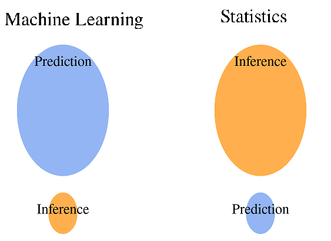

# Table of Contents

## Motivating example

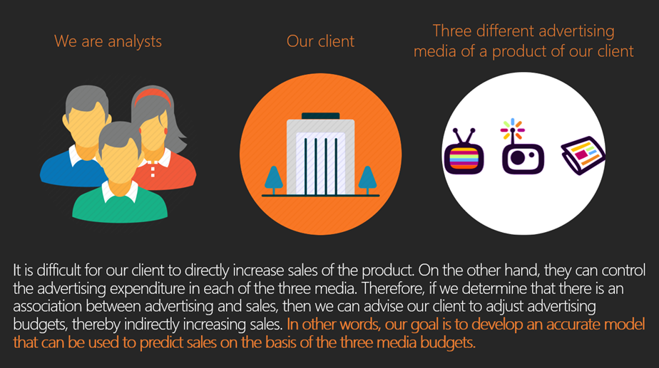

### Data loading and descriptive summary

```
import pandas as pd

df = pd.read_csv("data/Advertising.csv") # specify your data path here
df.head()
```

|  | TV | Radio | Newspaper | Sales |
| --- | --- | --- | --- | --- |
| 0 | 230.1 | 37.8 | 69.2 | 22.1 |
| 1 | 44.5 | 39.3 | 45.1 | 10.4 |
| 2 | 17.2 | 45.9 | 69.3 | 9.3 |
| 3 | 151.5 | 41.3 | 58.5 | 18.5 |
| 4 | 180.8 | 10.8 | 58.4 | 12.9 |

### Mathematical expression of data

We denote the dataset $\mathcal{D}$, where $\mathcal{D} = \{(\boldsymbol{x}_1, y_1), \cdots, (\boldsymbol{x}_N, y_N)\} = \{(\boldsymbol{x}_n, y_n)\}_{n=1}^{N}$, and

$$\boldsymbol{X} = \left[\begin{array}{ccc} x_{11} & \cdots & x_{1D} \\ \vdots & \ddots & \vdots \\ x_{N1} & \cdots & x_{ND} \\ \end{array} \right] = \left[ \begin{array}{c} \boldsymbol{x}_1^\top \\ \vdots \\ \boldsymbol{x}_N^\top \\ \end{array} \right], \ \ \ \ \ \boldsymbol{y} = \left[ \begin{array}{ccc} y_{1} \\ \vdots \\ y_{N} \\ \end{array} \right]$$

- Variables in $\boldsymbol{X}$ are called **feature** (or **independent variable**, **predictor**, **regressor**, **explanatory variable**).
- $\boldsymbol{y}$ is called **response** (or **dependent variable**, **regressand**, **target variable**).

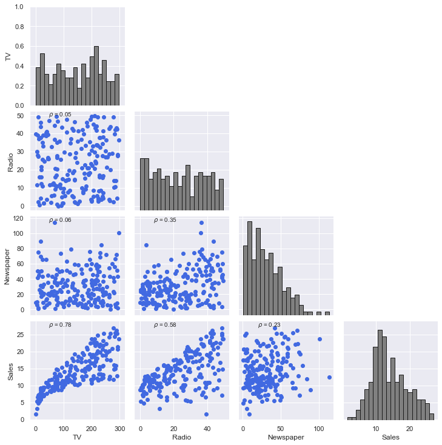

## Linear regression

### Multiple linear regression

Linear regression is the one that involves a linear combination of the input variables. Let $\boldsymbol{x}_n$ denote a vector of the input for the $n$th observation, than a **multiple linear regression** can be described as:

$$f(\boldsymbol{x}_n) = w_0 + w_1 x_1 + w_2 x_2 + \cdots + w_D x_D + \epsilon_n,$$

where $\epsilon_n$ is an i.i.d. random error. If $D=1$, the model is also called **simple linear regression**.

### Simple linear regression

When we plug in $x_1, \ldots, x_N$ into the estimated regression line $\hat{w}_0 + \hat{w}_1 x$, the **predicted values** can be obtained, that is

$$\hat{y}_n = \hat{w}_0 + \hat{w}_1 x_n,$$

for $n = 1, \ldots, N$

To estimate $w_0$ and $w_1$ we minimize the **sum of squared errors (SSE)**. We can rewrite it as the loss function of weights:

$$\mathcal{L}(w_0, w_1) = \sum_{n=1}^N \left[ y_n - (w_0 + w_1 x_n)\right]^2$$

The $\hat{w_0}$ and $\hat{w_1}$ that minimize $\mathcal{L}(w_0, w_1)$ are called the **least squares estimates (LSE)**.

\begin{align*} \frac{\partial }{\partial w_0} \mathcal{L}(w_0, w_1) & = \frac{\partial}{\partial w_0}\sum_{n=1}^N ( y_n - w_0 - w_1 x_n)^2 \\ & = \sum_{n=1}^N \frac{\partial}{\partial w_0}( y_n - w_0 - w_1 x_n)^2 \\ & = \sum_{n=1}^N 2 ( y_n - w_0 - w_1 x_n) (-1), \\ \frac{\partial }{\partial w_1} \mathcal{L}(w_0, w_1) & = \frac{\partial}{\partial w_1}\sum_{n=1}^N ( y_n - w_0 - w_1 x_n)^2 \\ & = \sum_{n=1}^N \frac{\partial}{\partial w_1}( y_n - w_0 - w_1 x_n)^2 \\ & = \sum_{n=1}^N 2 ( y_n - w_0 - w_1 x_n) (-x_n). \end{align*}

Setting both of these equal to $0$ gives us

\begin{align*} N w_0 + \left(\sum_{n=1}^{N} x_n \right)w_1 = & \ \sum_{n=1}^{N} y_n, \\ \left(\sum_{n=1}^{N} x_n \right) w_0 + \left(\sum_{n=1}^{N} x_n^2 \right) w_1 = & \ \sum_{n=1}^{N} x_n y_n. \end{align*}

Then we solve for $w_0$ and $w_1$

\begin{align*} \hat{w}_0 = & \ \bar{y} - \hat{w}_1 \bar{x},\\ \hat{w}_1 = & \ \frac{\sum x_i y_i - N \bar{x}\bar{y}}{\sum x_i^2 - N\bar{x}^2} = \frac{\sum(x_i - \bar{x})(y_i - \bar{y})}{\sum (x_i - \bar{x})^2}. \end{align*}

### Coefficient of determination

The total variability in $y$ is the **total sum of squares (SST)** is defined as

$$\text{SST} = \sum_{n=1}^N (y_n - \bar{y})^2,$$

and $\text{SST} - \text{SSE}$ is called the **regression sum of squares (SSR)**, defined as

$$\text{SSR} = \sum_{n=1}^N (\hat{y}_n - \bar{y})^2.$$

The **coefficient of determination** $\text{R}^2$ is defined as the proportion of the total variability that is explained (higher is better)

$$\text{R}^2 = \frac{\text{SSR}}{ \text{SST} } = 1 - \frac{\text{SSE}}{ \text{SST}}$$

### Absorbing the bias term

In multiple linear regression, we often absorb the bias term $w_0$ into the weight vector

$$ \boldsymbol{w} = \left[ \begin{array}{c} w_0 \\ w_1 \\ \vdots \\ w_D \\ \end{array} \right] $$

The feature input matrix and vectors are adjusted accordingly

$$ \boldsymbol{X} = \left[ \begin{array}{cccc} 1 & x_{11} & \cdots & x_{1D} \\ \vdots & \vdots & \ddots & \vdots \\ 1 & x_{N1} & \cdots & x_{ND} \\ \end{array} \right] = \left[ \begin{array}{c} \boldsymbol{x}_1^\top \\ \vdots \\ \boldsymbol{x}_N^\top \\ \end{array} \right], $$

where $\boldsymbol{x}_1^\top = [1, x_{11}, \ldots, x_{1D}]$

### Visualize multiple linear regression with two predictors

In a three-dimensional setting, with two predictors and one response, the regression line becomes a plane. The plane minimizes the sum of the squared vertical distances between each observation and the plane.

[interactive chart not shown]

### Estimating weights

#### Least squares

\begin{align*} \text{SSE} = \mathcal{L}(\boldsymbol{w}) = & \ {\boldsymbol\epsilon}^\top {\boldsymbol\epsilon} \\ = & \ (\boldsymbol{y} - \boldsymbol{X}\boldsymbol{w})^\top (\boldsymbol{y} - \boldsymbol{X}\boldsymbol{w}) \\ = & \ \boldsymbol{y}^\top \boldsymbol{y} - \boldsymbol{y}^\top \boldsymbol{X}\boldsymbol{w} - \boldsymbol{w}^\top \boldsymbol{X}^\top \boldsymbol{y} + (\boldsymbol{X}\boldsymbol{w})^\top \boldsymbol{X}\boldsymbol{w}. \end{align*}

Taking derivatives of SSE with respect to $\boldsymbol{w}$ gives

\begin{align*} \frac{\partial }{\partial \boldsymbol{w}} \mathcal{L}(\boldsymbol{w}) = & \ \frac{\partial }{\partial \boldsymbol{w}} \bigg\{ \boldsymbol{y}^\top \boldsymbol{y} - \boldsymbol{y}^\top \boldsymbol{X}\boldsymbol{w} - \boldsymbol{w}^\top \boldsymbol{X}^\top \boldsymbol{y} + (\boldsymbol{X}\boldsymbol{w})^\top \boldsymbol{X}\boldsymbol{w} \bigg\} \\ = & \ \frac{\partial }{\partial \boldsymbol{w}} \bigg\{ \boldsymbol{y}^\top \boldsymbol{y} - 2 \boldsymbol{y}^\top \boldsymbol{X}\boldsymbol{w} + \boldsymbol{w}^\top \boldsymbol{X}^\top \boldsymbol{X}\boldsymbol{w} \bigg\} \\ = & \ - 2 \boldsymbol{X}^\top \boldsymbol{y} + 2 \boldsymbol{X}^\top \boldsymbol{X}\boldsymbol{w} = 0. \end{align*}

Then

$$\widehat{\boldsymbol{w}} = (\boldsymbol{X}^\top \boldsymbol{X})^{-1} \boldsymbol{X}^\top \boldsymbol{y}.$$

#### Maximum likelihood

\begin{align*} \mathcal{L}(\boldsymbol{w}) = & \ f(\boldsymbol\epsilon; \boldsymbol{x}_n, \boldsymbol{w}) \\ = & \ \prod_{n = 1}^N f(\epsilon_n; \boldsymbol{x}_n, \boldsymbol{w}) \\ = & \ \prod_{n = 1}^N \frac{1}{\sqrt{2 \pi \sigma^2}} \exp\bigg\{ - \frac{(y_n - \boldsymbol{w}^\top\boldsymbol{x}_n)^2}{2 \sigma^2} \bigg\}, \end{align*}

The negative log likelihood (NLL) of $\mathcal{L}(\boldsymbol{w})$ is then

\begin{align*} \text{NLL} = & \ - \log\{ \mathcal{L}(\boldsymbol{w}) \} \\ = & \ - \sum_{n = 1}^N \log\{ f(\epsilon_n; \boldsymbol{x}_n, \boldsymbol{w}) \} \\ = & \ \frac{N}{2} \log\{2 \pi \sigma^2\} + \frac{1}{2 \sigma^2} \sum_{n = 1}^N (y_i - \boldsymbol{w}^\top\boldsymbol{x}_n)^2 \\ = & \ \frac{N}{2} \log\{2 \pi \sigma^2\} + \frac{1}{2 \sigma^2} \underbrace{(\boldsymbol{y} - \boldsymbol{X} \boldsymbol{w})^\top(\boldsymbol{y} - \boldsymbol{X} \boldsymbol{w})}_{= \text{SSE}}. \end{align*}

Since NLL is monotone decreasing and $\frac{n}{2} \log\{2 \pi \sigma^2\}$ has no $\boldsymbol{w}$ item, taking derivatives of $\text{NLL}$ with respect to $\boldsymbol{w}$ then gives the same result of LSE.

#### Gradient descent (GD)

Let $$\mathcal{J}(\boldsymbol{w}) = \frac{1}{2} \sum_{n=1}^{N}(f_{\boldsymbol{w}}(x_n) - y_n)^2 = \sum_{n=1}^{N} \mathcal{J}_n(\boldsymbol{w}),$$ where $\mathcal{J}_n(\boldsymbol{w}) = \frac{1}{2} (f_{\boldsymbol{w}}(x_n) - y_n)^2 $.

GD is also called **batch gradient descent (BGD)** in machine learning. The GD (or BGD) for linear regression can be expressed as

1: **Choose** initial guess $\boldsymbol{w}_0$ and learning rate $\alpha$
2: **Repeat** updating the approximation $$\boldsymbol{w}_i = \boldsymbol{w}_{i-1} - \alpha \nabla \mathcal{J}(\boldsymbol{w}_{i-1}) = \boldsymbol{w}_{i-1} - \alpha \sum_{n=1}^{N} \nabla \mathcal{J}_n(\boldsymbol{w}_{i-1})$$ until an approximate minimum is obtained, where $i$ is the iteration index starting from 1.
3: **Return** $\boldsymbol{w}$

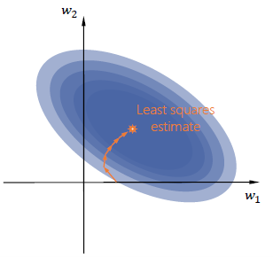

#### Stochastic gradient descent (SGD)

1: **Shuffle** the training data
2: **Choose** initial guess $\boldsymbol{w}_0$ and learning rate $\alpha$
3: **Process** one data point at the time and repeat updating the approximation
**for** $n = 1, \ldots, N$: $$\boldsymbol{w}_i = \boldsymbol{w}_{i-1} - \alpha \nabla \mathcal{J}_n (\boldsymbol{w}_{i-1})$$ until an approximate minimum is obtained, where $i$ is the iteration index starting from 1.
3: **Return** $\boldsymbol{w}$

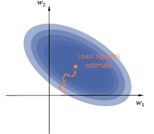

### Implementing linear regression in Python

#### Data preparation

We can use the machine learning library `sklearn` to implement linear regression model for this advertising sales project. Before we go to `sklearn` library, there are a few more things we need to do.

##### Data frame to ndarray

Firstly, we need to convert data frame of features and response into ndarray because the latter is the recognized data type for `sklearn` library.

We can use `to_numpy()` function or `values` function with `pandas` to do this conversion. For the response variable, we also need to use `flatten` function to convert the $N \times 1$ ndarray to $1 \times N$ ndarray

https://pandas.pydata.org/pandas-docs/stable/reference/api/pandas.DataFrame.to_numpy.html

https://numpy.org/doc/stable/reference/generated/numpy.ndarray.flatten.html

```
col_names = df.columns

x = df[col_names[:-1]].to_numpy()
y = df["Sales"].to_numpy()
y = y.flatten()
print(x)
print(y)
```

[output not shown]

[output not shown]

[output cut: 160 more lines]

[output not shown]

##### Training and test data split

Secondly, as the figure shown below, we need to split the given data into two parts/sets: training set and test set. This separation is necessary because it allows us to determine how well our model can predict "new" data. Here "new" data is data that the model has not seen before. If we train the model using a data set, then evaluate the model using the same data set, we would have no way to determine whether the model is good at fitting "new" data or only good at fitting the data it has already seen.

**Test set method**

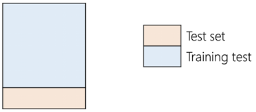

We can randomly or nonrandomly split data. In Python, we can use the `train_test_split` function from `sklearn.model_selection` to do data split. See here how to use this function https://scikit-learn.org/stable/modules/generated/sklearn.model_selection.train_test_split.html

```
from sklearn.model_selection import train_test_split

x_train, x_test, y_train, y_test = train_test_split(
    x, y, test_size=0.4, random_state=200
)
```

We can also cross validate the training and test sets. This is then called **k-fold cross validation**.

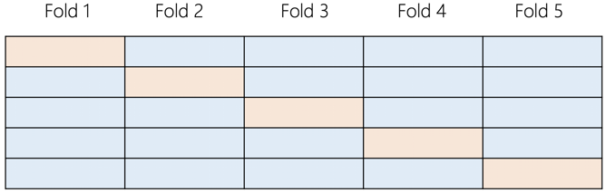

We can create different folds to do the training and testing, and then calculate the average model performance in both training and testing sets. In `sklearn`, we can also just use the `cross_val_score` to see the performance of test results for each fold.

```
from sklearn.model_selection import cross_val_score
```

https://scikit-learn.org/stable/modules/generated/sklearn.model_selection.cross_val_score.html#sklearn.model_selection.cross_val_score

#### Linear regression in sklearn

We can implement an ordinary least squares linear regression using `LinearRegression` from `sklearn`

https://scikit-learn.org/stable/modules/generated/sklearn.linear_model.LinearRegression.html#sklearn.linear_model.LinearRegression

```
from sklearn.linear_model import LinearRegression

reg = LinearRegression()
reg.fit(x_train, y_train)

print("Bias: %f" % reg.intercept_)
print("Feature weights: %s" % reg.coef_)
```

```
Bias: 3.109837
Feature weights: [0.04274781 0.19498501 0.00431096]
```

We can make predictions with the training data and the testing data

```
pred_train = reg.predict(x_train)
pred_test = reg.predict(x_test)

print(pred_train)
print(pred_test)
```

[output not shown]

```
=====

Training MSE

Multiple linear reg: 2.25944
=====

Test MSE

Multiple linear reg: 3.80321
```

```
array([-3.1365399 , -2.42566776, -1.58522508, -5.42615506, -2.79114519])
```

## Regularized linear regression

The regularized loss function can be expressed as follows:

\begin{align*} \mathcal{J}(\boldsymbol{w}) = & \ \mathcal{L}(\boldsymbol{w}) + \lambda \mathcal{E}(\boldsymbol{w}), \end{align*}

where $\mathcal{L}(\boldsymbol{w})$ is the data loss, $\mathcal{E}(\boldsymbol{w})$ is the regularizer, and $\lambda$ is the regularization coefficient.

### Lasso

L1 regularization term:

$$\mathcal{E}(\boldsymbol{w}) = \lVert \boldsymbol{w} \rVert_{1} = \sum_{d=1}^{D} |w_d|$$

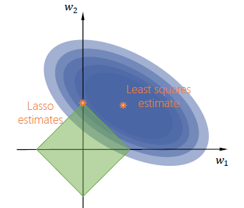

### Ridge

L2 regularization term:

$$\mathcal{E}(\boldsymbol{w}) = \lVert \boldsymbol{w} \rVert^{2}_{2} = \sum_{d=1}^{D} w^{2}_{d}$$

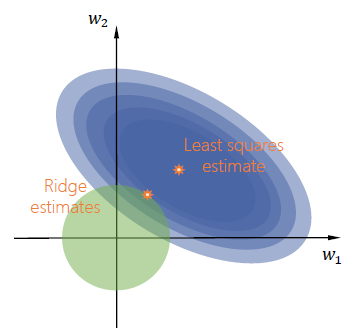

If $\mathcal{E}(\boldsymbol{w}) = \lVert \boldsymbol{w} \rVert^{2}_{2}$, then

\begin{align*} \mathcal{J}(\boldsymbol{w}) = & \ (\boldsymbol{y} - \boldsymbol{X}\boldsymbol{w})^\top (\boldsymbol{y} - \boldsymbol{X}\boldsymbol{w}) + \lambda \boldsymbol{w}^\top \boldsymbol{w}. \end{align*}

Taking derivatives of $\mathcal{J}$ with respect to $\boldsymbol{w}$ gives

\begin{align*} \frac{\partial }{\partial \boldsymbol{w}} \mathcal{J}(\boldsymbol{w}) = & \ \frac{\partial }{\partial \boldsymbol{w}} \bigg\{ \boldsymbol{y}^\top \boldsymbol{y} - \boldsymbol{y}^\top \boldsymbol{X}\boldsymbol{w} - \boldsymbol{w}^\top \boldsymbol{X}^\top \boldsymbol{y} + (\boldsymbol{X}\boldsymbol{w})^\top \boldsymbol{X}\boldsymbol{w} + \lambda \boldsymbol{w}^\top \boldsymbol{w} \bigg\} \\ = & \ - 2 \boldsymbol{X}^\top \boldsymbol{y} + 2 \boldsymbol{X}^\top \boldsymbol{X}\boldsymbol{w} + 2 \lambda \boldsymbol{w} = 0. \end{align*}

Then $\widehat{\boldsymbol{w}} = (\boldsymbol{X}^\top \boldsymbol{X} + \lambda \boldsymbol{I})^{-1} \boldsymbol{X}^\top \boldsymbol{y}$, where $\boldsymbol{I}$ is the identity matrix.

### Implementing regularized linear regression in Python

```
from sklearn.linear_model import Ridge

reg_ridge = Ridge(alpha=0.5)
reg_ridge.fit(x_train, y_train)

print("Bias: %f" % reg_ridge.intercept_)
print("Feature weights: %s" % reg_ridge.coef_)

pred_ridge_test = reg_ridge.predict(x_test)
print("MSE (ridge reg): %0.2f" % mean_squared_error(y_test, pred_ridge_test))
```

https://scikit-learn.org/stable/modules/generated/sklearn.linear_model.LinearRegression.html#sklearn.linear_model.LinearRegression

```
Bias: 3.109898
Feature weights: [0.04274782 0.19498062 0.00431217]
MSE (ridge reg): 3.80
```

```
from sklearn.linear_model import Lasso

reg_lasso = Lasso(alpha=1)
reg_lasso.fit(x_train, y_train)

print("Bias: %f" % reg_lasso.intercept_)
print("Feature weights: %s" % reg_lasso.coef_)

pred_lasso = reg_lasso.predict(x_test)
print("MSE (ridge linear): %0.2f" % mean_squared_error(y_test, pred_lasso))
```

https://scikit-learn.org/stable/modules/generated/sklearn.linear_model.Lasso.html#sklearn.linear_model.Lasso

```
Bias: 3.248477
Feature weights: [0.04264244 0.19113112 0.00302592]
MSE (ridge linear): 3.76
```

## Polynomial regression

The general polynomial regression model for a single predictor $x$ is

$$ y = w_0 + w_1 x + w_2 x^2 + w_3 x^3 + \cdots + w_D x^D + \epsilon, $$

where $D$ is called the **degree of the polynomial**. For lower degrees, the relationship has a specific name:

- $D = 2$ is called **quadratic**
- $D = 3$ is called **cubic**
- $D = 4$ is called **quartic**

Polynomial regression is considered to be a special case of multiple linear regression though it fits a non-linear relationship in the data. From the statistical estimation perspective, it is linear because the regression function $\mathbb{E}[y|X]$ is linear in parameters $\boldsymbol{w}$.

The mathematical setting of polynomial regression can be expressed as $\boldsymbol{y} = \boldsymbol{X} \boldsymbol{w} + \boldsymbol{\epsilon}$, where

$$ \boldsymbol{w} = \left[ \begin{array}{c} w_0 \\ w_1 \\ \vdots \\ w_D \\ \end{array} \right], \boldsymbol{X} = \left[ \begin{array}{ccccc} 1 & x_{1} & x_1^2 & \cdots & x_{1}^D \\ \vdots & \vdots & \vdots &\ddots & \vdots \\ 1 & x_{N} & x_N^2 &\cdots & x_{N}^D \\ \end{array} \right] = \left[ \begin{array}{c} \boldsymbol{x}_1^\top \\ \vdots \\ \boldsymbol{x}_N^\top \\ \end{array} \right], \boldsymbol{y} = \left[ \begin{array}{c} y_{1} \\ \vdots \\ y_{N} \\ \end{array} \right], \boldsymbol{\epsilon} = \left[ \begin{array}{c} \epsilon_{1} \\ \vdots \\ \epsilon_{N} \\ \end{array} \right]. $$

Here $\boldsymbol{X}$ is also called **Vandermonde matrix**. If the invertibility condition is guaranteed to hold if all the $x_n$ values are distinct. The unique least-squares solution is then $$\widehat{\boldsymbol{w}} = (\boldsymbol{X}^\top \boldsymbol{X})^{-1} \boldsymbol{X}^\top \boldsymbol{y}.$$

### Implementing polynomial regression in Python

Let's look at another dataset `Video_Games_Sales_2016.csv`. People generally think that games received low user scores always end up with bad sales in the market. Is it true or not?

|  | Global_Sales | User_Score |
| --- | --- | --- |
| 1 | 5.30 | 8.9 |
| 2 | 4.73 | 7.7 |
| 3 | 4.68 | 7.7 |
| 5 | 4.05 | 8.5 |
| 6 | 3.71 | 8.8 |
| ... | ... | ... |
| 14454 | 0.01 | 8.2 |
| 14455 | 0.01 | 6.6 |
| 14458 | 0.01 | 8.5 |
| 14459 | 0.01 | 6.7 |
| 14460 | 0.01 | tbd |

9738 rows × 2 columns

|  | User_Score | Global_Sales |
| --- | --- | --- |
| 91 | 9.4 | 0.627500 |
| 92 | 9.5 | 0.330000 |
| 93 | 9.6 | 0.370000 |
| 94 | 9.7 | 0.030000 |
| 95 | tbd | 0.187275 |

|  | User_Score | Global_Sales |
| --- | --- | --- |
| 90 | 9.3 | 0.630667 |
| 91 | 9.4 | 0.627500 |
| 92 | 9.5 | 0.330000 |
| 93 | 9.6 | 0.370000 |
| 94 | 9.7 | 0.030000 |

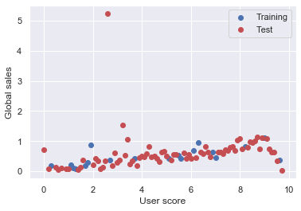

```
MSE (simple linear): 0.43533
MSE (poly linear): 0.42875
```

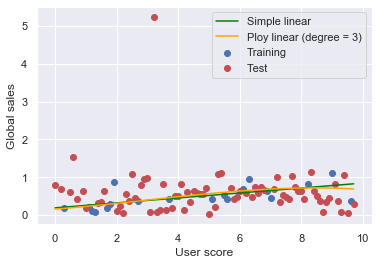

## Appendix: gradient decent

**Gradient descent**, also known as **steepest descent**, is an optimization algorithm for finding the **local minimum** of a function. To find a local minimum, the function "steps" in the direction of the negative of the gradient. **Gradient ascent** is the same as gradient descent, except that it steps in the direction of the positive of the gradient and therefore finds local maximums instead of minimums. The algorithm of gradient descent can be outlined as follows:

1: Choose initial guess $x_0$ and step size $\alpha$  
2: **for** k = 0, 1, 2, ... **do**  
3: $x_{k+1} = x_k - \alpha \nabla f(x_k)$  
4: **end for**

Let's find a local minimum for the function $f(x) = x^3-2x^2+2$

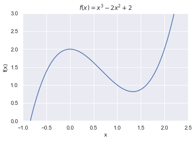

```
Local minimum occurs at: 1.3334253508453249
Number of steps: 17
```

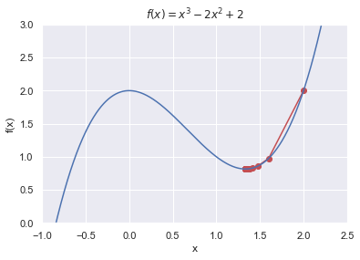

## Appendix: Implementing stochastic gradient descent in Python

We can also implement stochastic gradient descent for linear regression (with regularization) using `sklearn` library

```
from sklearn.pipeline import make_pipeline
from sklearn.linear_model import SGDRegressor
from sklearn.preprocessing import StandardScaler

# Always scale the input. The most convenient way is to use a pipeline.
reg_sgd = SGDRegressor(
    max_iter=100000,
    tol=1e-8,
    fit_intercept=True,
    eta0=0.001,
    loss="squared_loss",
    penalty="l2",
    random_state=100,
)
reg_sgd_pip = make_pipeline(StandardScaler(), reg_sgd)
reg_sgd_pip.fit(x_train, y_train)

pred_sgd_train = reg_sgd_pip.predict(x_train)
pred_sgd_test = reg_sgd_pip.predict(x_test)

print("MSE (ridge linear): %0.2f" % mean_squared_error(y_test, pred_sgd_test))
```

[output not shown]